# Behavioral Cloning Project

### Goal statement

In this project train a CNN model to clone driving behavior using camera images. Use Udacity provided simulator.

### To meet specifications, the project will require submitting five files:

- model.py (script used to create and train the model)
- drive.py (script to drive the car - feel free to modify this file)
- model.h5 (a trained Keras model)
- a report writeup file (either markdown or pdf)
- video.mp4 (a video recording of your vehicle driving autonomously around the track for at least one full lap)

### Setting up Simulation env

- Install Unity on ubuntu. There is no offitial support on Unity3D website. But luckily there is a debian version avialable when you google.
- Download the car simulator beta_simulator_linux.
- Setting up conda env 'carnd-term1'.
  - My GPU is already setup with tenssorflow v1.8.0 and keras v2.1.6 (py36_0)
  - And Nvidia Cuda 9.0
  - Hence the 'model_nvidia.h5' is having version keras other than carnd-term1, if needed i can downgrade keras.

```python
import matplotlib.pyplot as plt
import keras
from keras.models import Sequential
from keras import optimizers
from keras.layers import Flatten, Dense, Lambda, Activation, Dropout
from keras.layers import Conv2D, MaxPooling2D, Cropping2D, Reshape
from keras.callbacks import History
import tensorflow as tf
print("keras=",keras.__version__, ", tensorflow=", tf.VERSION)

#nvidia-smi
#nvcc --version
```

```
keras= 2.1.6 , tensorflow= 1.8.0
```

### classes and files

- bc_const = holds important constants
- BcProcesssImage = is used to load, process images.
- BcTrainData = is responsible read traing data and create 'generators'
- BcModel = Is the glue class. Does the training using various CNN keras models.
- model_*.h5 = saved model
- auto_mode_record.mp4 = recorded video using model_nvidia.h5 in autonomous mode
- CarND-Behavioral-Cloning-Visual.ipynb = writeup and visualization notebook.

```python
#project
from bc_helper import BcHelper
import bc_const
from bc_processs_image import BcProcesssImage
from bc_train_data import BcTrainData
from bc_model import BcModel
```

### Load traing data and create 'generators' for batch X (images), y (angles)

- load traing data + generator
- summary of the recordings

```python
bc_model= BcModel()

#load traing data + generator
#summary of the recodings
```

```
==================== config summary ================================ start
recording_root_dir: /home/lab/sim_data/my_capture
original_recording_root_dir: None
enable augmentation: False
enable multiple cameras: False
correction_factor: 0.2
train_test_split_size: 0.2
batch_size: 512
epochs: 20
Find all subfolder  with training data in : /home/lab/sim_data/my_capture
==================== config summary ================================ end
==================== recoding summary ================================ start
== records == (4180, 7)  in  /home/lab/sim_data/my_capture/center_anti_clock_wise/driving_log.csv
------------------------------------------
== records == (5760, 7)  in  /home/lab/sim_data/my_capture/center_clock_wise/driving_log.csv
------------------------------------------
== records == (3511, 7)  in  /home/lab/sim_data/my_capture/recovery_laps2/driving_log.csv
------------------------------------------
== records == (1863, 7)  in  /home/lab/sim_data/my_capture/bridge/driving_log.csv
------------------------------------------
== records == (525, 7)  in  /home/lab/sim_data/my_capture/recovery_laps3/driving_log.csv
------------------------------------------
== records == (2163, 7)  in  /home/lab/sim_data/my_capture/recovery_laps4/driving_log.csv
------------------------------------------
== records == (2329, 7)  in  /home/lab/sim_data/my_capture/clock_wise/driving_log.csv
------------------------------------------
*** head: after reindex and shuffle=                                         c_camera_img  \
0  /home/lab/sim_data/my_capture/center_clock_wis...
1  /home/lab/sim_data/my_capture/recovery_laps4/I...
2  /home/lab/sim_data/my_capture/clock_wise/IMG/c...
3  /home/lab/sim_data/my_capture/clock_wise/IMG/c...
4  /home/lab/sim_data/my_capture/clock_wise/IMG/c...

                                        l_camera_img  \
0  /home/lab/sim_data/my_capture/center_clock_wis...
1  /home/lab/sim_data/my_capture/recovery_laps4/I...
2  /home/lab/sim_data/my_capture/clock_wise/IMG/l...
3  /home/lab/sim_data/my_capture/clock_wise/IMG/l...
4  /home/lab/sim_data/my_capture/clock_wise/IMG/l...

```

[output cut: 11 more lines]

```
3       1.0    0.0  30.189920
4       0.0    0.0  14.740610
==================== recodings summary ================================ end


================== generator   =================================== start
recording total =  (20331, 7)
self.train_samples= (16264, 7)
self.validation_samples= (4067, 7)
_generator shape: (16264, 7)
(512, 160, 320, 3) (512,)
_generator shape: (4067, 7)
(512, 160, 320, 3) (512,)
None
================== generator  =================================== end
```

### Histogram on angles in training data

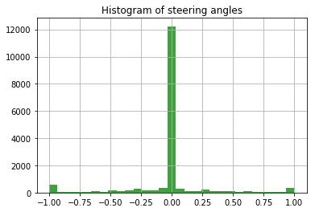

```python
bc_model.histogram_angle()
```

### Example images recored during trainging mode on car-simualtor

- images from three cameras
- images normalized
- fliped version

```python
def show_images(images_hash,  squeeze=False, name=""):
    img_names = [*images]
    images_to_show=len(img_names)
    print( "===", name, "===")
    print( img_names)

    fig = plt.figure(figsize=(20,20))
    counter=1
    for img_name in img_names:
        img = images_hash[img_name]
        plt.subplot(4, 3, counter, xticks=[], yticks=[])
        if squeeze:
            plt.imshow(img.squeeze())
        else:
            plt.imshow(img)
        plt.title(img_name)
        counter += 1
    fig.tight_layout()
    plt.savefig('./out_images/img_'+name+'.png' )
    plt.show()
```

### Random selection of a record

```python
images , data = bc_model.visualization_imgs()
print("random record number=", data['idx'] )
for key, value in data["record"].iteritems():
    print(key, "=", value)
```

```
random record number= 35
c_camera_img = /home/lab/sim_data/my_capture/recovery_laps2/IMG/center_2018_10_06_17_29_43_211.jpg
l_camera_img = /home/lab/sim_data/my_capture/recovery_laps2/IMG/left_2018_10_06_17_29_43_211.jpg
r_camera_img = /home/lab/sim_data/my_capture/recovery_laps2/IMG/right_2018_10_06_17_29_43_211.jpg
steering_angle = 0.0
throttle = 0.0
break = 0.0
speed = 11.48442
```

### Image loading and augmentation

```
=== camera_images_and_augmentation ===
['c_camera_img', 'c_camera_img.norm', 'c_camera_img.flip', 'l_camera_img', 'l_camera_img.norm', 'l_camera_img.flip', 'r_camera_img', 'r_camera_img.norm', 'r_camera_img.flip']
```

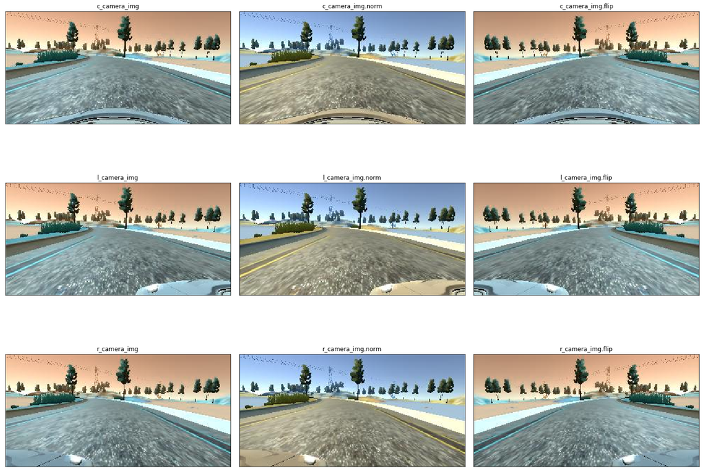

```python
show_images(images, name ="camera_images_and_augmentation")
```

### Model

```python
from keras.utils.vis_utils import plot_model
print("summary  model_single_layer")
plot_model(bc_model.model_lenet() , to_file='./out_images/model_single_layer.png', show_shapes=True, show_layer_names=True)
bc_model.model_single_layer().summary()
```

```
summary  model_single_layer
_________________________________________________________________
Layer (type)                 Output Shape              Param #
=================================================================
lambda_2 (Lambda)            (None, 160, 320, 3)       0
_________________________________________________________________
cropping2d_2 (Cropping2D)    (None, 64, 200, 3)        0
_________________________________________________________________
conv2d_3 (Conv2D)            (None, 31, 99, 32)        896
_________________________________________________________________
max_pooling2d_3 (MaxPooling2 (None, 15, 49, 32)        0
_________________________________________________________________
dropout_3 (Dropout)          (None, 15, 49, 32)        0
_________________________________________________________________
flatten_2 (Flatten)          (None, 23520)             0
_________________________________________________________________
dense_4 (Dense)              (None, 1)                 23521
=================================================================
Total params: 24,417
Trainable params: 24,417
Non-trainable params: 0
_________________________________________________________________
```

```python
print("summary  model_lenet")
plot_model(bc_model.model_lenet() , to_file='./out_images/model_lenet.png', show_shapes=True, show_layer_names=True)
bc_model.model_lenet().summary()
```

```
summary  model_lenet
_________________________________________________________________
Layer (type)                 Output Shape              Param #
=================================================================
lambda_4 (Lambda)            (None, 160, 320, 3)       0
_________________________________________________________________
cropping2d_4 (Cropping2D)    (None, 64, 200, 3)        0
_________________________________________________________________
conv2d_6 (Conv2D)            (None, 30, 98, 6)         456
_________________________________________________________________
max_pooling2d_6 (MaxPooling2 (None, 15, 49, 6)         0
_________________________________________________________________
conv2d_7 (Conv2D)            (None, 6, 23, 16)         2416
_________________________________________________________________
max_pooling2d_7 (MaxPooling2 (None, 3, 11, 16)         0
_________________________________________________________________
flatten_4 (Flatten)          (None, 528)               0
_________________________________________________________________
dense_8 (Dense)              (None, 120)               63480
_________________________________________________________________
activation_5 (Activation)    (None, 120)               0
_________________________________________________________________
dropout_6 (Dropout)          (None, 120)               0
_________________________________________________________________
dense_9 (Dense)              (None, 84)                10164
_________________________________________________________________
activation_6 (Activation)    (None, 84)                0
_________________________________________________________________
dropout_7 (Dropout)          (None, 84)                0
_________________________________________________________________
dense_10 (Dense)             (None, 1)                 85
=================================================================
Total params: 76,601
Trainable params: 76,601
Non-trainable params: 0
_________________________________________________________________
```

```python
print("summary  model_nvidia")
plot_model(bc_model.model_lenet() , to_file='./out_images/model_nvidia.png', show_shapes=True, show_layer_names=True)
bc_model.model_nvidia().summary()
```

```
summary  model_nvidia
_________________________________________________________________
Layer (type)                 Output Shape              Param #
=================================================================
lambda_6 (Lambda)            (None, 160, 320, 3)       0
_________________________________________________________________
cropping2d_6 (Cropping2D)    (None, 64, 200, 3)        0
_________________________________________________________________
conv2d_10 (Conv2D)           (None, 30, 98, 24)        1824
_________________________________________________________________
conv2d_11 (Conv2D)           (None, 13, 47, 36)        21636
_________________________________________________________________
conv2d_12 (Conv2D)           (None, 5, 22, 48)         43248
_________________________________________________________________
conv2d_13 (Conv2D)           (None, 3, 20, 64)         27712
_________________________________________________________________
conv2d_14 (Conv2D)           (None, 1, 18, 64)         36928
_________________________________________________________________
flatten_6 (Flatten)          (None, 1152)              0
_________________________________________________________________
dropout_10 (Dropout)         (None, 1152)              0
_________________________________________________________________
dense_14 (Dense)             (None, 100)               115300
_________________________________________________________________
activation_9 (Activation)    (None, 100)               0
_________________________________________________________________
dropout_11 (Dropout)         (None, 100)               0
_________________________________________________________________
dense_15 (Dense)             (None, 50)                5050
_________________________________________________________________
activation_10 (Activation)   (None, 50)                0
_________________________________________________________________
dropout_12 (Dropout)         (None, 50)                0
_________________________________________________________________
dense_16 (Dense)             (None, 10)                510
_________________________________________________________________
dense_17 (Dense)             (None, 1)                 11
=================================================================
Total params: 252,219
Trainable params: 252,219
Non-trainable params: 0
_________________________________________________________________
```

### Training and saving model

```
model.h5 trained

dict_keys(['val_loss', 'val_acc', 'loss', 'acc'])
```

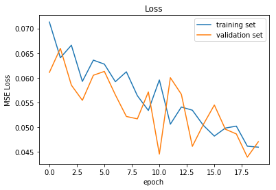

```python
# bc_model = BcModel()
# bc_model.histogram_angle()
# images, data = bc_model.visualization_imgs()
bc_model.train(bc_model.model_nvidia(), 'model')
bc_model.plot_history(name='model_nvidia')
```

### Test smaller model - model_single_layer

```
model_single_layer.h5 trained

dict_keys(['val_loss', 'val_acc', 'loss', 'acc'])
```

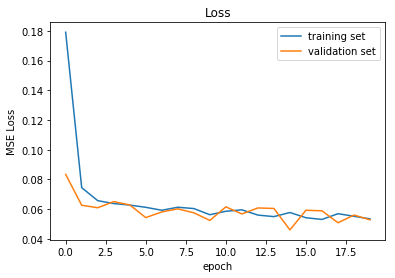

```python
bc_model.train(bc_model.model_single_layer(), 'model_single_layer')
bc_model.plot_history(name='model_single_layer')
```

### Test smaller model - model_lenet

```
model_lenet.h5 trained

dict_keys(['val_loss', 'val_acc', 'loss', 'acc'])
```

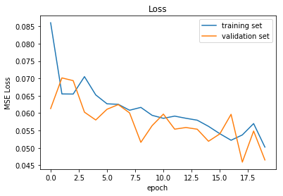

```python
# bc_model.model_lenet().summary()
# bc_model.model_single_layer().summary()
# bc_model.model_nvidia().summary()
bc_model.train(bc_model.model_lenet(), 'model_lenet')
bc_model.plot_history(name='model_lenet')
```